# Crash course: Geospatial datavisualisering

Jeppe Vierø

April 2022

## Pakker

```r
library(tidyverse)
library(janitor)
library(sf)
library(tmap)
library(rnaturalearth)
```

## Datastrukturer

### Verden før `sf`

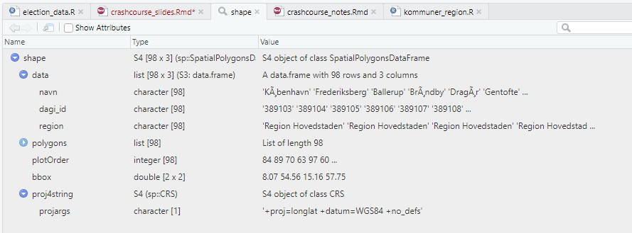

Data ifølge {sp}

### Der er intet mystisk eller unikt ved “spatialt” data

```r
tribble(~lat, ~lon,
        55.71372762470475, 9.556222451831141)
```

```
## # A tibble: 1 x 2
##     lat   lon
##   <dbl> <dbl>
## 1  55.7  9.56
```

```r
df <- tribble(~name,~n_champs,~lat, ~lon,
              "Vejle Boldklub",5,55.71372762470475, 9.556222451831141,
              "Aarhus Gymnastikforening",5,56.13193948661876, 10.196519237914524,
              "AC Horsens",0,55.87162048058711, 9.857707600274574)

df <- df %>%
  st_as_sf(coords = c("lon", "lat"),
           crs = 4326)

tmap_mode("view")

tm_shape(df) +
  tm_bubbles(size = 2,
             col = "n_champs")
```

[interactive chart not shown]

## Datatyper

### `points`

#### Load data

```r
urbana <- st_read(dsn = "data/urbana",
                  layer = "urbana")
```

```r
class(urbana$geometry)
```

```
## [1] "sfc_POINT" "sfc"
```

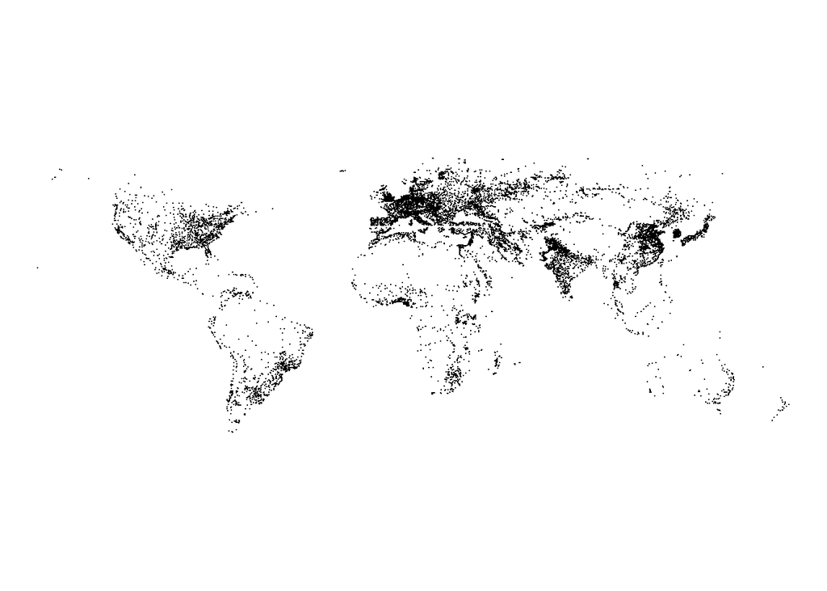

```r
ggplot() +
  geom_sf(data = urbana,
          size = .01) +
  theme_void()
```

### `lines`

#### Load data

```r
rivers <- st_read(dsn = "data/rivers",
                  layer = "rivers")
```

```r
class(rivers$geometry)
```

```
## [1] "sfc_MULTILINESTRING" "sfc"
```

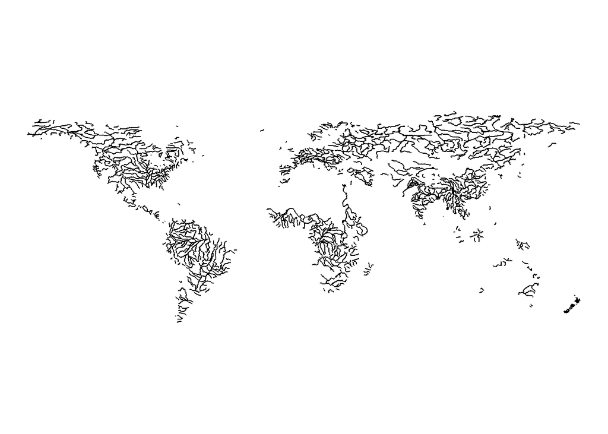

```r
ggplot() +
  geom_sf(data = rivers) +
  theme_void()
```

### `polygons`

#### Load data

```r
europe <- st_read(dsn = "data/europe",
                  layer = "europe")
```

```r
class(europe$geometry)
```

```
## [1] "sfc_MULTIPOLYGON" "sfc"
```

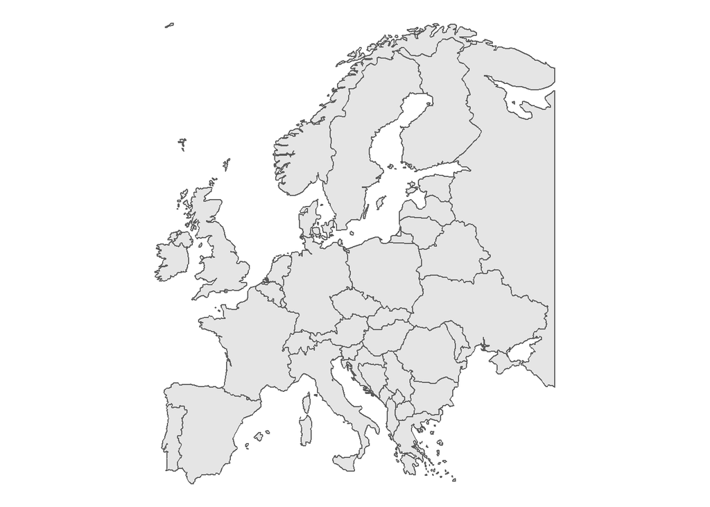

```r
ggplot() +
  geom_sf(data = europe) +
  theme_void()
```

## Visualisér med `ggplot2`

Lad os starte med at vise kortet over Europa! Fordi vi bruger `sf`-pakken til det hele, kan vi bruge `tidyverse`-funktioner til at manipulere data med.

Vi har ikke brug for at vise koordinater hen ad akserne, så vi bruger `theme_void()`:

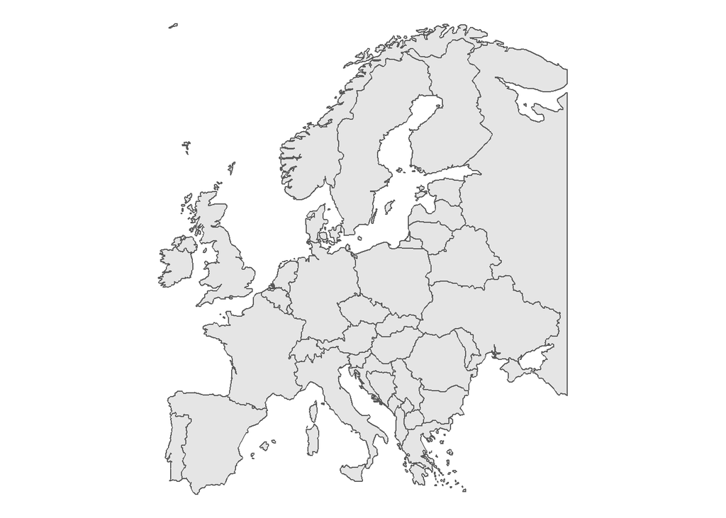

```r
ggplot() +
  geom_sf(data = europe) +
  theme_void()
```

Ikke dumt! Lad os tilføje vores data over byer. Det gør vi let ved at tilføje endnu en “geometry” til vores ``ggplot`:

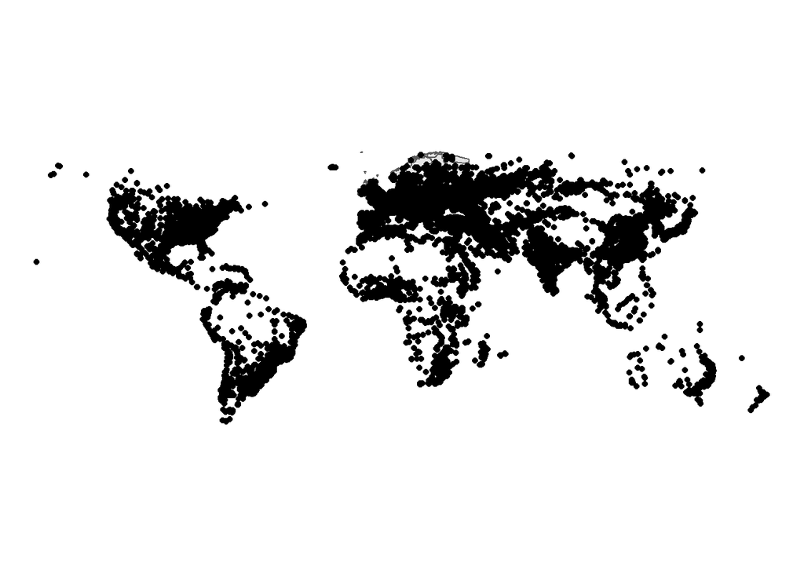

```r
ggplot() +
  geom_sf(data = europe) +
  geom_sf(data = urbana) +
  theme_void()
```

Aha! Det er jo meget fedt, at vi har data på byer rundt i hele verden, men lige her gør det nok mere skade end gavn.

Husk, at `tidyverse`-funktioner kan bruges på `sf`-datasæt, akkurat som på klassiske datasæt. Hvis der var en regionsvariabel i bydatasættet, kunne vi derfor let filtrere alt uden for Europa væk vha. `dplyr::filter()`. Det er der desværre ikke, så vi må ty til andre tricks.

Heldigvis har `sf-pakken` en lang række værktøjer, der hjælper os med at manipulere data. Fx kan vi bruge `st_intersection()` til at beskære ét datasæt med et andet:

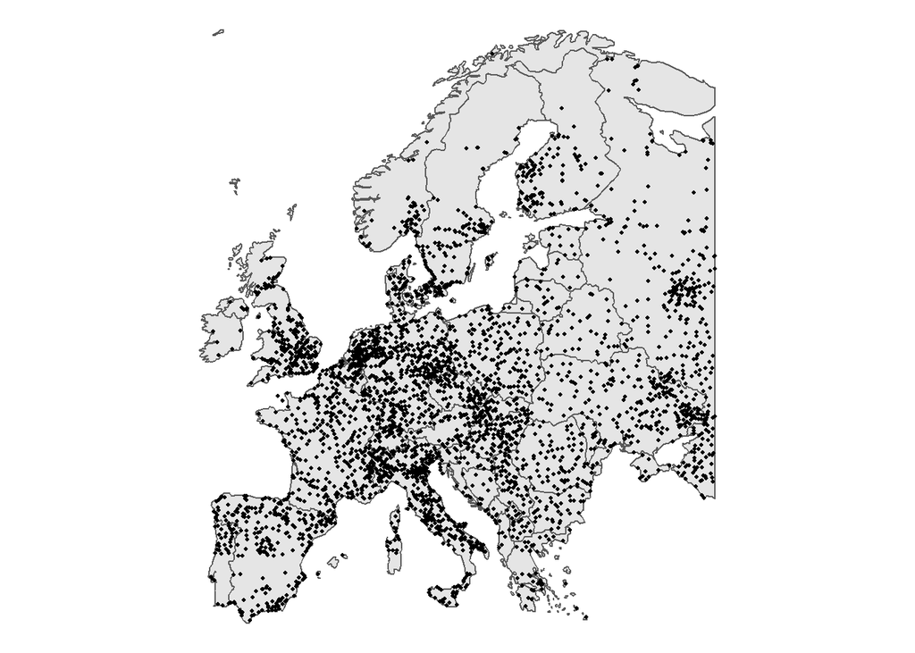

```r
eu_cities <- urbana %>%
  st_intersection(.,
                  europe)

ggplot() +
  geom_sf(data = europe) +
  geom_sf(data = eu_cities,
          size = .8) +
  theme_void()
```

Meget bedre! Men, det bliver en smule tætpakket med alle de prikker. Lad os lege lidt med det visuelle:

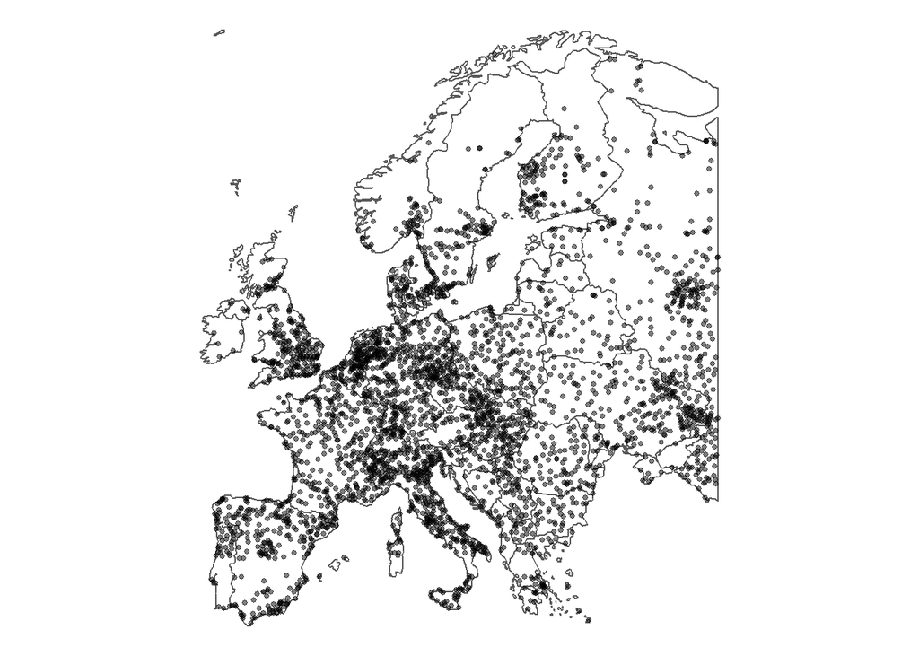

```r
ggplot() +
  geom_sf(data = europe, fill = "white") +
  geom_sf(data = eu_cities,
          size = 1,
          alpha = .5) +
  theme_void()
```

Da vi beskar bydatasættet med shapefilen med Europa-kortet, tilføjede den automatisk data fra sidstnævnte.

```r
eu_cities
```

```
## Simple feature collection with 3424 features and 8 fields
## Geometry type: POINT
## Dimension:     XY
## Bounding box:  xmin: -9.251242 ymin: 36.1835 xmax: 40.98619 ymax: 69.74173
## Geodetic CRS:  WGS 84
## First 10 features:
##      scalerank featurecla area_sqkm min_zoom  tmp          cntry           unit
## 3294         9 Urban area     8.936      7.7 3294 United Kingdom         Jersey
## 3293         8 Urban area    34.616      7.6 3293 United Kingdom       Guernsey
## 3231         7 Urban area    18.935      7.0 3231 United Kingdom    Isle of Man
## 3198         9 Urban area    10.900      7.7 3198 United Kingdom United Kingdom
## 3199         9 Urban area    11.659      7.7 3199 United Kingdom United Kingdom
## 3201         9 Urban area    10.329      7.7 3201 United Kingdom United Kingdom
## 3202         7 Urban area    80.259      7.0 3202 United Kingdom United Kingdom
## 3203         9 Urban area     6.911      7.7 3203 United Kingdom United Kingdom
## 3204         8 Urban area    32.645      7.6 3204 United Kingdom United Kingdom
## 3205         9 Urban area    10.634      7.7 3205 United Kingdom United Kingdom
##               sub_re                   geometry
## 3294 Northern Europe POINT (-2.098328 49.19537)
## 3293 Northern Europe POINT (-2.550666 49.47685)
## 3231 Northern Europe  POINT (-4.48212 54.16456)
## 3198 Northern Europe POINT (-3.312512 57.65061)
## 3199 Northern Europe POINT (-3.635281 57.62275)
## 3201 Northern Europe POINT (-4.213206 57.47909)
## 3202 Northern Europe  POINT (-2.128716 57.1617)
## 3203 Northern Europe POINT (-2.467238 56.73593)
## 3204 Northern Europe POINT (-2.607162 56.59364)
## 3205 Northern Europe POINT (-2.738971 56.52185)
```

Det kan vi bruge til at tilføje flere farver til vores kort!

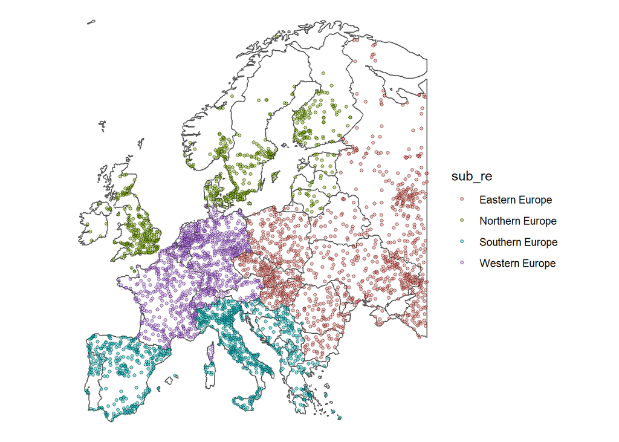

```r
ggplot() +
  geom_sf(data = europe, fill = "white") +
  geom_sf(data = eu_cities,
          aes(fill = sub_re),
          shape = 21,
          size = 1,
          alpha = .5) +
  theme_void()
```

Ikke dumt! Men det er stadig svært at udlede så meget substantielt. Lad os prøve noget nyt: bruge de data, vi fik smidt på byerne før til at summere nogle mere aggregerede mål. På den måde kan vi visualisere landene (polygoner) med information fra byerne (punkter).

Her har vi to spatiale datasæt:

1. Et over lande (polygoner)
2. Et over byer (punkter), med lande- og regionsvariable fra det første

Det kan selvfølgelig kombineres! Igen, vi kan bruge alle de `tidyverse`-tricks vi kender og elsker.

Fordi vi i sidste ende gerne vil visualisere polygonerne, har vi ikke brug for det spatiale element i bydatasættet. Det skal bare merges igen. Derfor *sletter vi `geometry`-listen*. Hvorfor ?

1. `sf` vil ikke merge to spatiale datasæt med en klassisk `*_join()`. Den vil meget hellere joine på det spatiale, men det har vi ikke brug for her
2. Spatialt data er tungt. Som tommelfingerregel bør I derfor altid droppe `geometry`’en, når I ikke skal bruge den. Lad mig vise det nedenfor:

```r
library(tictoc)

# aggreger vores areal-variabel inden for lande med spatialt data
tic()
city_cntry <- eu_cities %>%
  group_by(cntry) %>%
  summarize(area = sum(area_sqkm)) %>%
  ungroup()
toc()
```

```
## 1.9 sec elapsed
```

```r
# aggreger vores areal-variabel inden for lande med ikke-spatialt data
temp <- eu_cities %>%
  st_drop_geometry()

tic()
city_cntry <- temp %>%
  group_by(cntry) %>%
  summarize(area = sum(area_sqkm)) %>%
  ungroup()
toc() ; rm(temp)
```

```
## 0 sec elapsed
```

Forskellen er jo ikke enorm, men den er klar! Hvis I arbejder med større datasæt, kan det hurtigt blive en enorm fordel at tænke over, hvornår det spatiale aspekt af data mest bare er en hæmsko.

Nå, I digress. Tilbage til visualiseringen. Det nye `city_cntry` data kan vi let joine med vores landepolygoner med en simpel `left_join()`, og så er vi back in business!

```r
df_europe <- europe %>%
  tidylog::left_join(.,
                     city_cntry,
                     by = "cntry")
```

```r
df_europe <- df_europe %>%
  mutate(area = ifelse(is.na(area),
                       0,
                       area))
```

Nu kan vi lave vores nye kort!

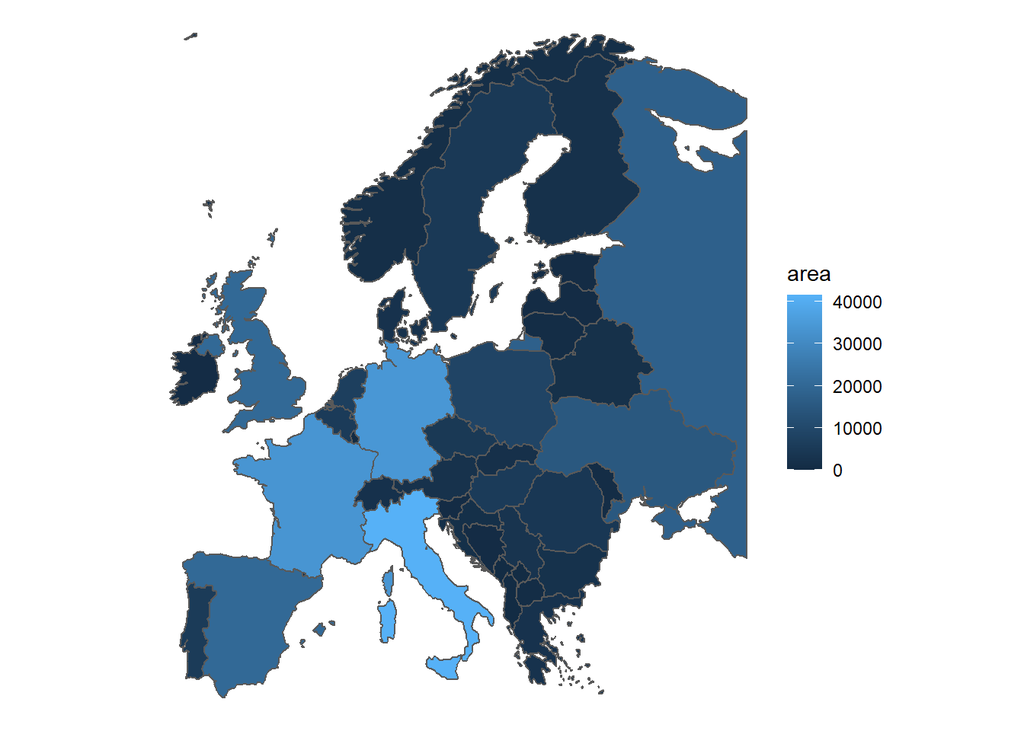

```r
ggplot() +
  geom_sf(data = df_europe,
          aes(fill = area)) +
  theme_void()
```

Bum! Det var lige det, vi gerne ville have. Men faktisk er det lidt dumt, at Rusland er med på kortet, når det ikke rigtigt er en del af Europa – og fordi vi alligevel kun viser en lille del af det. Lad os fjerne det med en simpel `filter()`:

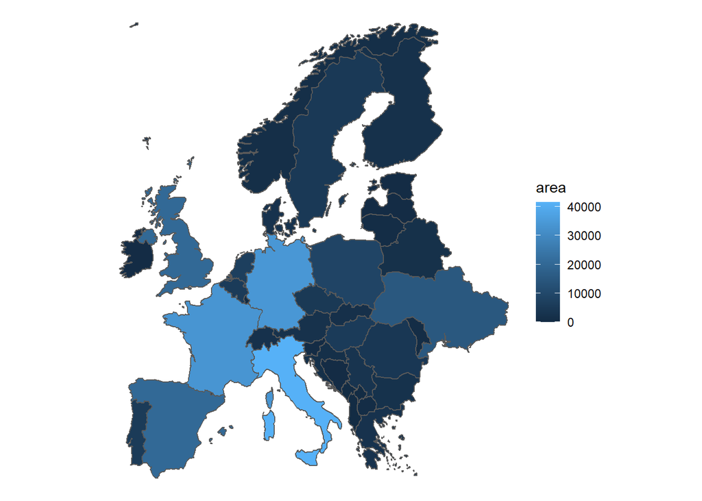

```r
df_europe <- df_europe %>%
  filter(cntry != "Russia")

ggplot() +
  geom_sf(data = df_europe,
          aes(fill = area)) +
  theme_void()
```

Sådan! Nu vi er i gang, kan vi godt prøve at gøre det lidt pænt.

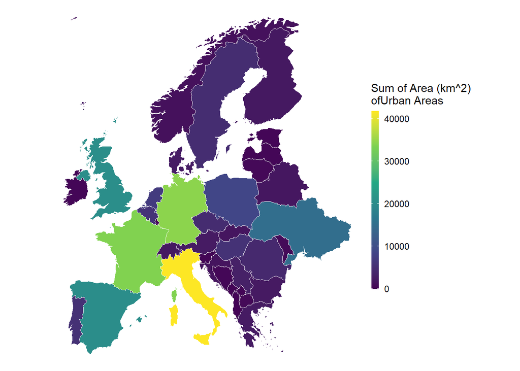

```r
ggplot() +
  geom_sf(data = df_europe,
          aes(fill = area),
          color = "white",
          size = .01) +
  scale_fill_viridis_c(name = "Sum of Area (km^2)\nofUrban Areas") +
  theme_void() +
  guides(fill = guide_colorbar(direction = "vertical",
                               barheight = 12,
                               barwidth = .5))
```

## CRS: Projektioner af kloden

> *“All models are wrong, but some are useful”*  
> – George Box

Vi vil ofte gerne vise en globe i et 2D-rum. Problemet er, at er **fysisk umuligt**. Det kan simpelthen ikke lade sig gøre. Det betyder, at alle kort I nogensinde har set (glober undtaget) er forkerte på én eller anden måde. Tror I mig ikke? [Se her!](https://www.youtube.com/watch?v=kIID5FDi2JQ).

Det er her, CRS’er (Coordinate Reference Systems) kommer ind i billedet. For at “løse” det helt fundamentale problem (og fordi glober er ret besværlige at gå rundt med) er der udviklet [en lang række projektioner](https://en.wikipedia.org/wiki/List_of_map_projections). Vi bruger med andre ord disse matematiske projektioner til at *projicere* en globe (oftest vores egen klode) i et 2D-rum på en måde, der fungerer til formålet.

Alle disse projektioner er “forkerte” på en eller anden måde, og der er **altid** en eller anden forvrængning af størrelse, form eller retninger. Men, de er jo ikke udviklet for sjov. De er udviklet, fordi vi har brug for dem, og fordi de er brugbare. De er ikke allesammen lige brugbare, og de er sjældent lige brugbare til samme formål. Med en let omskrivning af ovenstående citat kan vi beskrive dem som:

> → All **projections** are wrong, but some are useful

Det nok mest berømte eksempel på en projektion (og på, at de aldrig er perfekte…) er Mercator-projektionen (*EPSG 4326 / 3857*, se mere [her](https://gist.github.com/keum/7441007)). Den er berømt og berygtet for at repræsentere visse dele af kloden (især Afrika og Sydamerika) som værende mindre, end de faktisk er. Det er jo uden tvivl rigtigt nok. Se billedet nedenfor, hvor cirklerne angiver areal relativt til faktisk areal. Den mere ukvalificerede del af kritikken går så langt som til at fremhæve, at den er “forkert”. Det er den, men det er alle alternativer også.

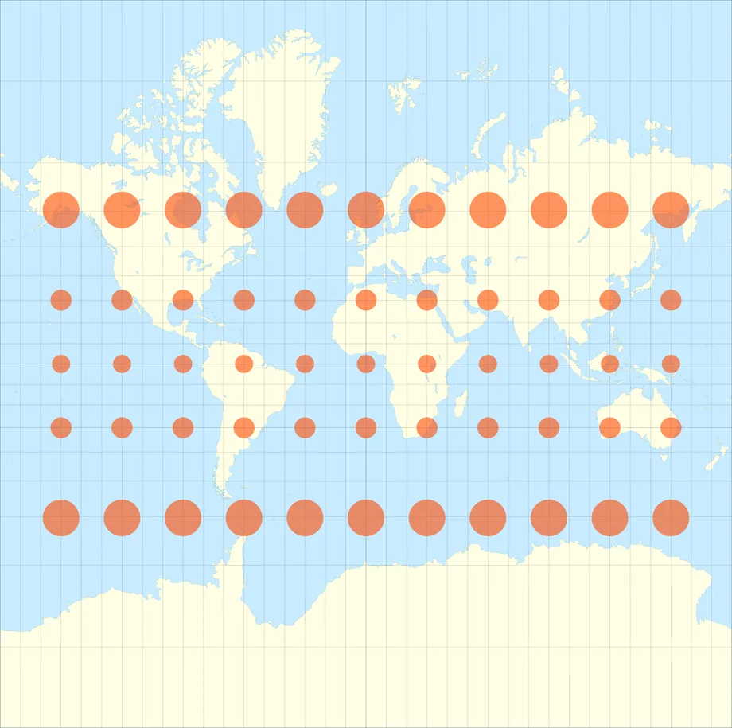

Der er også spekuleret meget i, at projektionen skulle være udviklet med henblik på mentalt at (re)producere europæisk dominans, fordi den fremstiller Afrika som langt mindre relativt til Europa end det faktisk er:

> *“These maps of Africa, drawn up by a small group of western cartographers, symbolically reinforced Europeans’ sense of control over their mapped territories and subjects, but they didn’t betray much in the way of real information. Though they would have been seen as objective and impartial at the time, in retrospect it is clear how subjective, ideologically driven, and, in many ways, fantastical they were.”*  
> [– James Wan](https://www.theguardian.com/world/2014/apr/02/google-maps-gets-africa-wrong)

Det er noget sludder. Det er også et ulogisk argument. I det 15. århundrede, hvor Mercator-projektionen blev udviklet, havde europæerne ikke behov for at fremstille det afrikanske argument som værende “småt” for at legitimere kolonialisering. Der var masser af “legitimitet” at hente qua religion, “civilisation”, vanvittige idéer om “raceforskelle” osv. Tværtimod havde europæiske magthavere, om noget, [interesse i at fremstille deres oversøiske besiddelser som værende så store og imponerende som muligt](http://america.aljazeera.com/opinions/2015/6/every-map-youve-ever-seen-of-africa-is-right.html).

Mercator-projektionen er uden tvivl relateret til europæisk kolonialisme, men på en lidt mere indirekte måde. Den var nemlig [**helt eminent at navigere efter**](https://www.britannica.com/science/Mercator-projection)**, især på meget lange maritime strækninger** og med simpel teknologi. Som, fx, på turene over Atlanterhavet i det 15. århundrede. På disse længere ture giver Mercator-projektionen ikke *helt* den korteste rute, men det giver den mest bullet-proof kurs.

### Hvilken CRS skal I bruge?

Det vigtigste er, at I bruger den samme CRS i alle jeres objekter. Et lille trick er at definere en værdi i starten, som I løbende kan referere til. På den måde skal I kun ændre den ét sted, hvis det bliver aktuelt

```r
my_crs <- 4326

# df <- read_sf() %>%
#   st_transform(4326)
#
# map <- read_sf() %>%
#   st_transform(3359)
#
# st_crs(df) == st_crs(map)
#
# df <- df %>%
#   st_transform(crs = my_crs)
#
# map <- map %>%
#   st_transform(crs = my_crs)
#
# st_crs(df) == st_crs(map)
```

For mere information om brug af CRS’er i R, se:

- Oversigt over EPSG-koder: `rgdal::make_EPSG()`
- [“Overview of Coordinate Reference Systems (CRS) in R”](https://www.nceas.ucsb.edu/sites/default/files/2020-04/OverviewCoordinateReferenceSystems.pdf)
- [Lesson 3. Coordinate Reference System and Spatial Projection](https://www.earthdatascience.org/courses/earth-analytics/spatial-data-r/intro-to-coordinate-reference-systems/)
- [Choosing a projection](http://www.geo.hunter.cuny.edu/~jochen/gtech201/lectures/lec6concepts/map%20coordinate%20systems/how%20to%20choose%20a%20projection.htm)

## Vil du vide mere?

- [R for Data Science](https://r4ds.had.co.nz/)
- [Geocomputation with R](https://geocompr.robinlovelace.net/)